# Sun2 overexpression bulk RNA-seq analysis

Jian Zhang (zhang.jian@yale.edu)

2019-09-23

group A: Sample_XH_1916, Sample_XH_1917, Sample_XH_1918

group B: Sample_XH_1919, Sample_XH_1920, Sample_XH_1921

Using *Tophat2* and *Cuffdiff* to do reads mapping, gene quantification and DEGs identification. Run the scripts in Yale linux server.

`perl 1.run.tophat2.parallel.pl /home/zj76/project/Xiao_Sun2_ad2/Sample_XH_1916_to_Sample_XH_1924`

`perl 2.run.cuffdiff.with.slurm.pl /home/zj76/project/database/mm10/Mus_musculus.GRCm38.96.gtf XH_19_16_17_18,XH_19_19_20_21,XH_19_22_23_24`

`sbatch cuffdiff.sh.run.slurm.sh`

`perl 3.mapping.sta.pl`

`perl 4.HTSeq.counts.table.pl`;`perl 4.FPKM.table.from.cuffnorm.pl`

`perl 5.FPKM.fiter.pl`

`perl 6.FPKM.sta.pl gene.FPKM.filtered.table`

`perl 7.DEGs.from.cuffdiff.pl`

```r
library(ggplot2)
library(pheatmap)
library(tidyverse)
library(dplyr)
library(org.Mm.eg.db)
library(org.Hs.eg.db)
library(GO.db)
library(clusterProfiler)
library(enrichplot)
library(fgsea)
library(DOSE)
library(RcisTarget)
library(DT)
library(reshape2)
library(visNetwork)
library(biomaRt)
library(VennDiagram)
```

## Mapping statistics

```r
mapping = read.table("mapping.sta.table",header=T, row.names = 1)
mapping
```

|  | paired_reads | overall_read_mapping_rate | Aligned_pairs | multiple_alignments | discordant_alignments | concordant_pair_alignment_rate |
| --- | --- | --- | --- | --- | --- | --- |
| XH_1916 | 52806942 | 80.1% | 39650598 | 1982096 | 325733 | 74.5% |
| XH_1917 | 26293856 | 78.6% | 19186767 | 955265 | 272662 | 71.9% |
| XH_1918 | 47369574 | 79.1% | 34202297 | 1956831 | 585023 | 71.0% |
| XH_1919 | 22287331 | 30.5% | 6059036 | 387758 | 201338 | 26.3% |
| XH_1920 | 21869725 | 28.0% | 5407757 | 334516 | 212152 | 23.8% |
| XH_1921 | 23486297 | 75.4% | 15448119 | 954818 | 391364 | 64.1% |
| XH_1922 | 61907223 | 75.4% | 41777722 | 2678952 | 945144 | 66.0% |
| XH_1923 | 25363506 | 76.6% | 17528244 | 922664 | 253236 | 68.1% |
| XH_1924 | 62489154 | 79.5% | 45889856 | 2422248 | 577445 | 72.5% |

## Samples correlation

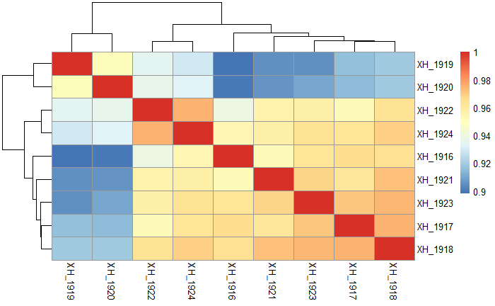

```r
fpkm = read.table("gene.FPKM.filtered.table", header=T, row.names = 1)
b=cor(fpkm,method="spearman") #method = c("pearson", "kendall", "spearman")
pheatmap(b)
```

## Differential expressed genes (DEGs)

XH_16_17_18.VS.XH_19_20_21 up: 278; down: 42

XH_16_17_18.VS.XH_22_23_24 up: 132; down: 30

XH_19_20_21.VS.XH_22_23_24 up: 7; down: 92

### XH_16_17_18.VS.XH_19_20_21

```r
a_vs_b_degs = read.table("DEGs/XH_16_17_18.VS.XH_19_20_21.DEGs.table", header=T, row.names = 1)
datatable(a_vs_b_degs,filter="top")
```

|  | gene_id | gene | locus | sample_1 | sample_2 | status | value_1 | value_2 | log2.fold_change. | test_stat | p_value | q_value | significant | regulation |
| --- | --- | --- | --- | --- | --- | --- | --- | --- | --- | --- | --- | --- | --- | --- |
| ENSMUSG00000078851 | ENSMUSG00000078851 | Hist3h2a | 11:58954684-58978050 | XH_16_17_18 | XH_19_20_21 | OK | 1.51672 | 9.53021 | 2.6515532287151 | 4.59304 | 5e-05 | 0.00468291 | yes | up |
| ENSMUSG00000031163 | ENSMUSG00000031163 | Glod5 | X:8004199-8018492 | XH_16_17_18 | XH_19_20_21 | OK | 1.58031 | 5.11737 | 1.69519495690264 | 2.37289 | 0.0002 | 0.0144655 | yes | up |
| ENSMUSG00000040584 | ENSMUSG00000040584 | Abcb1a | 5:8660076-8748575 | XH_16_17_18 | XH_19_20_21 | OK | 1.73616 | 3.94279 | 1.18331696305096 | 1.93538 | 0.0002 | 0.0144655 | yes | up |
| ENSMUSG00000014773 | ENSMUSG00000014773 | Dll1 | 17:15367353-15379475 | XH_16_17_18 | XH_19_20_21 | OK | 7.93364 | 21.7226 | 1.45314195133022 | 2.38696 | 5e-05 | 0.00468291 | yes | up |
| ENSMUSG00000045009 | ENSMUSG00000045009 | Prrt3 | 6:113493638-113501931 | XH_16_17_18 | XH_19_20_21 | OK | 1.91664 | 3.99165 | 1.05840584341882 | 2.16909 | 5e-05 | 0.00468291 | yes | up |
| ENSMUSG00000071267 | ENSMUSG00000071267 | Zfp942 | 17:21926959-21962464 | XH_16_17_18 | XH_19_20_21 | OK | 0.96223 | 2.38303 | 1.30834342878195 | 2.1331 | 0.0005 | 0.0294552 | yes | up |
| ENSMUSG00000058173 | ENSMUSG00000058173 | Smco4 | 9:15493431-15545260 | XH_16_17_18 | XH_19_20_21 | OK | 11.2681 | 4.46796 | -1.3345560971646 | -2.51744 | 5e-05 | 0.00468291 | yes | down |
| ENSMUSG00000030401 | ENSMUSG00000030401 | Rtn2 | 7:19282623-19296160 | XH_16_17_18 | XH_19_20_21 | OK | 14.0885 | 6.64184 | -1.08486314208218 | -2.40667 | 5e-05 | 0.00468291 | yes | down |
| ENSMUSG00000028278 | ENSMUSG00000028278 | Rragd | 4:32983036-33022180 | XH_16_17_18 | XH_19_20_21 | OK | 4.01171 | 9.46545 | 1.23845377554979 | 2.31006 | 0.00035 | 0.0227112 | yes | up |
| ENSMUSG00000038763 | ENSMUSG00000038763 | Alpk3 | 7:81057599-81105612 | XH_16_17_18 | XH_19_20_21 | OK | 0.876109 | 2.82217 | 1.68762261746165 | 1.85625 | 0.00015 | 0.0116579 | yes | up |

[output cut: 310 more lines]

### XH_16_17_18.VS.XH_22_23_24

```r
a_vs_c_degs = read.table("DEGs/XH_16_17_18.VS.XH_22_23_24.DEGs.table", header=T, row.names = 1)
datatable(a_vs_c_degs,filter="top")
```

|  | gene_id | gene | locus | sample_1 | sample_2 | status | value_1 | value_2 | log2.fold_change. | test_stat | p_value | q_value | significant | regulation |
| --- | --- | --- | --- | --- | --- | --- | --- | --- | --- | --- | --- | --- | --- | --- |
| ENSMUSG00000026443 | ENSMUSG00000026443 | Lrrn2 | 1:132880272-132940005 | XH_16_17_18 | XH_22_23_24 | OK | 0.136352 | 0.905835 | 2.73191242212764 | 2.3495 | 5e-05 | 0.00468291 | yes | up |
| ENSMUSG00000026628 | ENSMUSG00000026628 | Atf3 | 1:191170295-191218039 | XH_16_17_18 | XH_22_23_24 | OK | 18.535 | 8.68543 | -1.09358293410693 | -2.57964 | 5e-05 | 0.00468291 | yes | down |
| ENSMUSG00000027347 | ENSMUSG00000027347 | Rasgrp1 | 2:117279992-117343001 | XH_16_17_18 | XH_22_23_24 | OK | 0.682689 | 1.72824 | 1.34000316651144 | 2.1782 | 0.00015 | 0.0116579 | yes | up |
| ENSMUSG00000078503 | ENSMUSG00000078503 | Zfp990 | 4:145510758-145539188 | XH_16_17_18 | XH_22_23_24 | OK | 2.43509 | 10.3246 | 2.08403888936324 | 2.01729 | 0.0008 | 0.0417436 | yes | up |
| ENSMUSG00000030103 | ENSMUSG00000030103 | Bhlhe40 | 6:108577038-108666925 | XH_16_17_18 | XH_22_23_24 | OK | 12.9517 | 5.43913 | -1.25169366100946 | -2.09653 | 5e-05 | 0.00468291 | yes | down |
| ENSMUSG00000031216 | ENSMUSG00000031216 | Stard8 | X:99003247-99074728 | XH_16_17_18 | XH_22_23_24 | OK | 1.28269 | 3.92183 | 1.61235445762296 | 2.6915 | 5e-05 | 0.00468291 | yes | up |
| ENSMUSG00000053367 | ENSMUSG00000053367 | Epp13 | 7:6252709-6282066 | XH_16_17_18 | XH_22_23_24 | OK | 7.89451 | 16.4358 | 1.05792005207361 | 2.16061 | 0.00015 | 0.0116579 | yes | up |
| ENSMUSG00000024422 | ENSMUSG00000024422 | Dhx16 | 17:35879818-35892670 | XH_16_17_18 | XH_22_23_24 | OK | 98.5377 | 199.424 | 1.01709134087592 | 2.23077 | 0.00015 | 0.0116579 | yes | up |
| ENSMUSG00000042686 | ENSMUSG00000042686 | Jph1 | 1:16898184-17097889 | XH_16_17_18 | XH_22_23_24 | OK | 1.90274 | 0.583205 | -1.70600344443635 | -2.75788 | 5e-05 | 0.00468291 | yes | down |
| ENSMUSG00000115428 | ENSMUSG00000115428 | Gm41290 | 15:34021994-34037780 | XH_16_17_18 | XH_22_23_24 | OK | 0.241153 | 0.992726 | 2.04144682010814 | 2.46799 | 0.0007 | 0.0379718 | yes | up |

[output cut: 152 more lines]

### XH_19_20_21.VS.XH_22_23_24

```r
b_vs_c_degs = read.table("DEGs/XH_19_20_21.VS.XH_22_23_24.DEGs.table", header=T, row.names = 1)
datatable(b_vs_c_degs,filter="top")
```

|  | gene_id | gene | locus | sample_1 | sample_2 | status | value_1 | value_2 | log2.fold_change. | test_stat | p_value | q_value | significant | regulation |
| --- | --- | --- | --- | --- | --- | --- | --- | --- | --- | --- | --- | --- | --- | --- |
| ENSMUSG00000078851 | ENSMUSG00000078851 | Hist3h2a | 11:58954684-58978050 | XH_19_20_21 | XH_22_23_24 | OK | 9.53021 | 1.8143 | -2.39309497496067 | -4.61777 | 5e-05 | 0.00468291 | yes | down |
| ENSMUSG00000071267 | ENSMUSG00000071267 | Zfp942 | 17:21926959-21962464 | XH_19_20_21 | XH_22_23_24 | OK | 2.38303 | 0.952465 | -1.32305912942337 | -2.09696 | 0.0009 | 0.0458637 | yes | down |
| ENSMUSG00000064141 | ENSMUSG00000064141 | Zfp69 | 4:120930136-120951699 | XH_19_20_21 | XH_22_23_24 | OK | 2.83217 | 0.814575 | -1.79778842268348 | -2.24614 | 5e-05 | 0.00468291 | yes | down |
| ENSMUSG00000103322 | ENSMUSG00000103322 | Gm37404 | 3:62123206-62123565 | XH_19_20_21 | XH_22_23_24 | OK | 58.5231 | 21.4054 | -1.45103139658437 | -2.95924 | 5e-05 | 0.00468291 | yes | down |
| ENSMUSG00000064796 | ENSMUSG00000064796 | Terc | 3:96414436-96414859 | XH_19_20_21 | XH_22_23_24 | OK | 19.6863 | 0.700818 | -4.81200834491034 | -4.8706 | 0.00025 | 0.0173995 | yes | down |
| ENSMUSG00000091405 | ENSMUSG00000091405 | Hist2h4 | 3:96261681-96263311 | XH_19_20_21 | XH_22_23_24 | OK | 2.38467 | 0.219509 | -3.44143763679411 | -4.02588 | 5e-05 | 0.00468291 | yes | down |
| ENSMUSG00000072761 | ENSMUSG00000072761 | Gm6712 | 17:17294442-17319511 | XH_19_20_21 | XH_22_23_24 | OK | 10.854 | 4.16507 | -1.38181416631776 | -2.14503 | 0.00055 | 0.0316616 | yes | down |
| ENSMUSG00000051627 | ENSMUSG00000051627 | Hist1h1e | 13:23583669-23622558 | XH_19_20_21 | XH_22_23_24 | OK | 9.92677 | 0.304962 | -5.02462297501036 | -4.51551 | 0.00015 | 0.0116579 | yes | down |
| ENSMUSG00000069793 | ENSMUSG00000069793 | Slfn9 | 11:82978389-82991830 | XH_19_20_21 | XH_22_23_24 | OK | 2.19051 | 0.933062 | -1.23122194737632 | -2.15834 | 0.0006 | 0.0336119 | yes | down |
| ENSMUSG00000060678 | ENSMUSG00000060678 | Hist1h4c | 13:23697634-23698454 | XH_19_20_21 | XH_22_23_24 | OK | 28.7337 | 1.72671 | -4.05664607025601 | -6.8 | 5e-05 | 0.00468291 | yes | down |

[output cut: 89 more lines]

### Overlap of up-regulated DEGs

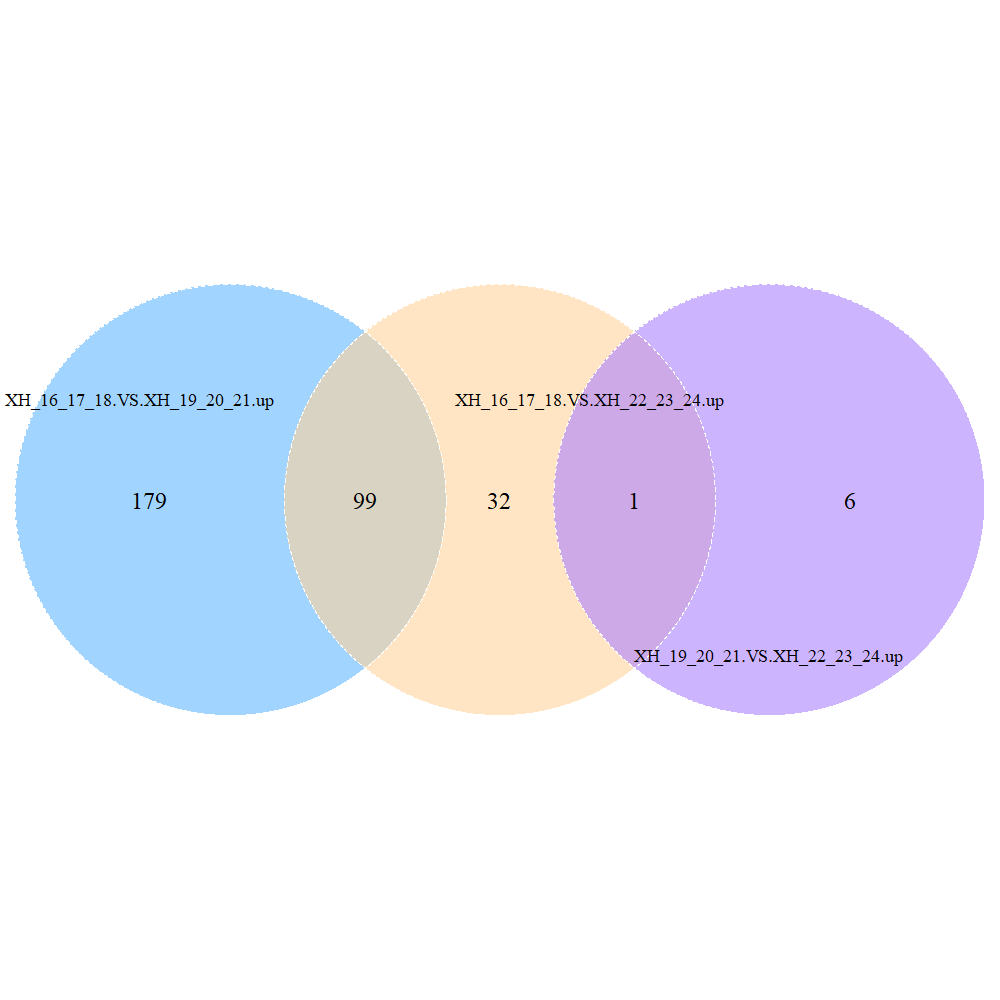

```r
png(filename = "overlap_of_up.png",width = 1000, height = 1000)
venn.plot <- venn.diagram(
  x=list(A=a_vs_b_degs[a_vs_b_degs$regulation == "up",]$gene,
         B=a_vs_c_degs[a_vs_c_degs$regulation == "up",]$gene,
         C=b_vs_c_degs[b_vs_c_degs$regulation == "up",]$gene),
  #filename="overlap_of_up.png",
  filename=NULL,
  #height = 3000, width = 3000,
  resolution =600,
  imagetype="png",
  category.names=c("XH_16_17_18.VS.XH_19_20_21.up","XH_16_17_18.VS.XH_22_23_24.up","XH_19_20_21.VS.XH_22_23_24.up"),
  col="white",
  fill=c(colors()[616], colors()[38], colors()[468]),
  alpha=rep(0.6,3),
  lwd=rep(1,3),
  lty=rep(2,3),
  cex=2,
  cat.dist=c(-0.07, -0.07, -0.05),
  cat.cex=1.5,
  #cat.pos=c(300, 60, 180),
  #cat.pos = c(-10, 10),
  cat.default.pos = 'outer')
grid.draw(venn.plot)
invisible(dev.off())
knitr::include_graphics("overlap_of_up.png")
```

The 99 overlaps between XH_16_17_18.VS.XH_19_20_21.up and XH_16_17_18.VS.XH_22_23_24.up are list as below:

```r
intersect(a_vs_b_degs[a_vs_b_degs$regulation == "up",]$gene,a_vs_c_degs[a_vs_c_degs$regulation == "up",]$gene)
```

```
 [1] "Stard8"        "Epp13"         "Gm34653"       "Aff1"          "Nos1"          "Pla1a"         "Sun2"          "Gm5134"
 [9] "Ttc39c"        "Efhc2"         "Gsta3"         "Sycp1"         "Sh2d4b"        "Kalrn"         "Platr16"       "Ubxn2a"
[17] "Cyct"          "Obox6"         "Plekhg1"       "Rcsd1"         "Rab38"         "Arhgap30"      "Ceacam20"      "Atp2b4"
[25] "Cdhr1"         "1700019A02Rik" "Klhl13"        "Ttn"           "Sept1"         "Tfpi"          "Prmt8"         "Itpka"
[33] "Gm26564"       "Galnt6"        "Jam2"          "Usp26"         "Slc4a5"        "2300002M23Rik" "Prrc1"         "Sall3"
[41] "Arl14epl"      "Nxf3"          "Elobl"         "Ephx2"         "Cnga3"         "Pnma5"         "Tspan32"       "H2-M6-ps"
[49] "Gm48218"       "Tdrd12"        "Mcf2"          "Lpar1"         "Aurkc"         "Ccno"          "A2m"           "Calcoco2"
[57] "Zfp534"        "Foxd3"         "D630039A03Rik" "Nt5e"          "Lncenc1"       "Smtnl1"        "Gm364"         "Gm10323"
[65] "Fbp2"          "Gm18336"       "Mirg"          "Lrmp"          "Vwa3b"         "Rian"          "Axin2"         "Lama3"
[73] "H2-M5"         "Platr14"       "Abcc2"         "Myo1f"         "Ooep"          "Meg3"          "AC141882.2"    "Zfp985"
[81] "Sox21"         "Platr25"       "Gm17167"       "2410137M14Rik" "Accsl"         "Msln"          "Flvcr2"        "Ak7"
[89] "Dusp27"        "Egfl6"         "C78283"        "Tek"           "Morc1"         "Ubd"           "Platr7"        "Cdx1"
[97] "Manba"         "Plagl1"        "Was"
```

The 1 overlap between XH_16_17_18.VS.XH_22_23_24.up and XH_19_20_21.VS.XH_22_23_24.up is list as below:

```r
intersect(b_vs_c_degs[b_vs_c_degs$regulation == "up",]$gene,a_vs_c_degs[a_vs_c_degs$regulation == "up",]$gene)
```

```
[1] "Gm28661"
```

### Overlap of down-regulated DEGs

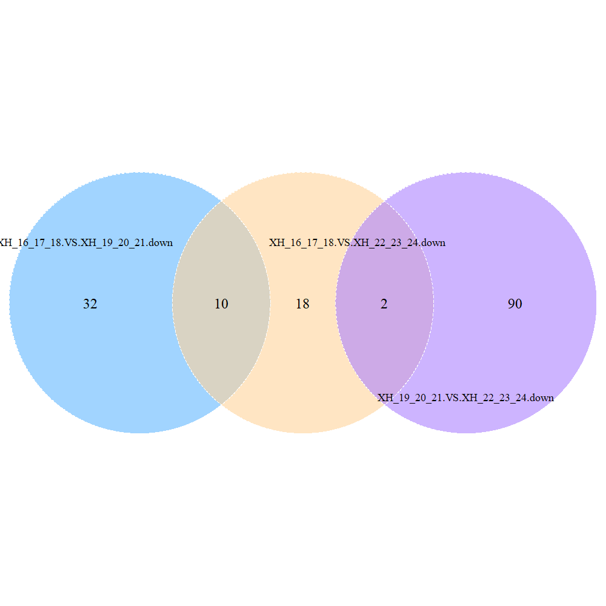

```r
png(filename = "overlap_of_down.png",width = 1000, height = 1000)
venn.plot <- venn.diagram(
  x=list(A=a_vs_b_degs[a_vs_b_degs$regulation == "down",]$gene,
         B=a_vs_c_degs[a_vs_c_degs$regulation == "down",]$gene,
         C=b_vs_c_degs[b_vs_c_degs$regulation == "down",]$gene),
  #filename="overlap_of_up.png",
  filename=NULL,
  #height = 3000, width = 3000,
  resolution =600,
  imagetype="png",
  category.names=c("XH_16_17_18.VS.XH_19_20_21.down","XH_16_17_18.VS.XH_22_23_24.down","XH_19_20_21.VS.XH_22_23_24.down"),
  col="white",
  fill=c(colors()[616], colors()[38], colors()[468]),
  alpha=rep(0.6,3),
  lwd=rep(1,3),
  lty=rep(2,3),
  cex=2,
  cat.dist=c(-0.07, -0.07, -0.05),
  cat.cex=1.5,
  #cat.pos=c(300, 60, 180),
  #cat.pos = c(-10, 10),
  cat.default.pos = 'outer')
grid.draw(venn.plot)
invisible(dev.off())
knitr::include_graphics("overlap_of_down.png")
```

The 10 overlaps between XH_16_17_18.VS.XH_19_20_21.down and XH_16_17_18.VS.XH_22_23_24.down are list as below:

```r
intersect(a_vs_b_degs[a_vs_b_degs$regulation == "down",]$gene,a_vs_c_degs[a_vs_c_degs$regulation == "down",]$gene)
```

```
 [1] "Lrp3"     "Herpud1"  "Trib3"    "Epha8"    "Gm26532"  "Chac1"    "Mir670hg" "Rasd2"    "Cldn7"    "Pcsk9"
```

The 2 overlap2 between XH_16_17_18.VS.XH_22_23_24.down and XH_19_20_21.VS.XH_22_23_24.down is list as below:

```r
intersect(b_vs_c_degs[b_vs_c_degs$regulation == "down",]$gene,a_vs_c_degs[a_vs_c_degs$regulation == "down",]$gene)
```

```
[1] "Slfn9"   "Slc15a2"
```

## GO enrichment

### BP subontologies for XH_16_17_18.VS.XH_19_20_21 DEGs

```r
# GO enrichment for DEGs
formula_res <- compareCluster(
  gene~regulation,
  data=a_vs_b_degs,
  fun="enrichGO",
  OrgDb="org.Mm.eg.db",
  keyType = "SYMBOL",
  ont          = "BP",
  pAdjustMethod = "BH",
  pvalueCutoff  = 0.01,
  qvalueCutoff  = 0.05
)
# Run GO enrichment test and merge terms that are close to each other to remove result redundancy
lineage1_ego <- clusterProfiler::simplify(
  formula_res,
  cutoff=0.5,
  by="p.adjust",
  select_fun=min
)
```

```r
#datatable(lineage1_ego@compareClusterResult,filter="top")
```

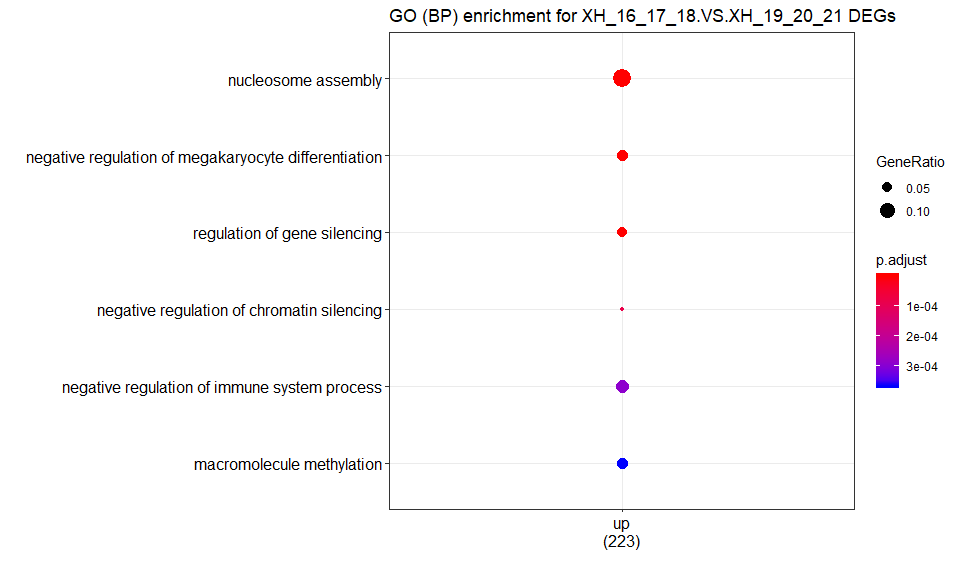

```r
# Plot both analysis results
dotplot(lineage1_ego, title="GO (BP) enrichment for XH_16_17_18.VS.XH_19_20_21 DEGs", showCategory=6)
```

### BP subontologies for XH_16_17_18.VS.XH_22_23_24 DEGs

```r
# GO enrichment for DEGs
formula_res <- compareCluster(
  gene~regulation,
  data=a_vs_c_degs,
  fun="enrichGO",
  OrgDb="org.Mm.eg.db",
  keyType = "SYMBOL",
  ont          = "BP",
  pAdjustMethod = "BH",
  pvalueCutoff  = 0.01,
  qvalueCutoff  = 0.05
)
# Run GO enrichment test and merge terms that are close to each other to remove result redundancy
lineage1_ego <- clusterProfiler::simplify(
  formula_res,
  cutoff=0.5,
  by="p.adjust",
  select_fun=min
)
```

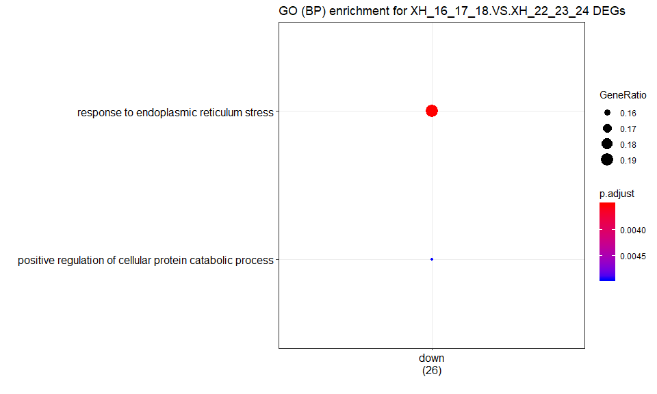

```r
# Plot both analysis results
dotplot(lineage1_ego, title="GO (BP) enrichment for XH_16_17_18.VS.XH_22_23_24 DEGs", showCategory=6)
```

### BP subontologies for XH_19_20_21.VS.XH_22_23_24 DEGs

```r
# GO enrichment for DEGs
formula_res <- compareCluster(
  gene~regulation,
  data=b_vs_c_degs,
  fun="enrichGO",
  OrgDb="org.Mm.eg.db",
  keyType = "SYMBOL",
  ont          = "BP",
  pAdjustMethod = "BH",
  pvalueCutoff  = 0.01,
  qvalueCutoff  = 0.05
)
# Run GO enrichment test and merge terms that are close to each other to remove result redundancy
lineage1_ego <- clusterProfiler::simplify(
  formula_res,
  cutoff=0.5,
  by="p.adjust",
  select_fun=min
)
```

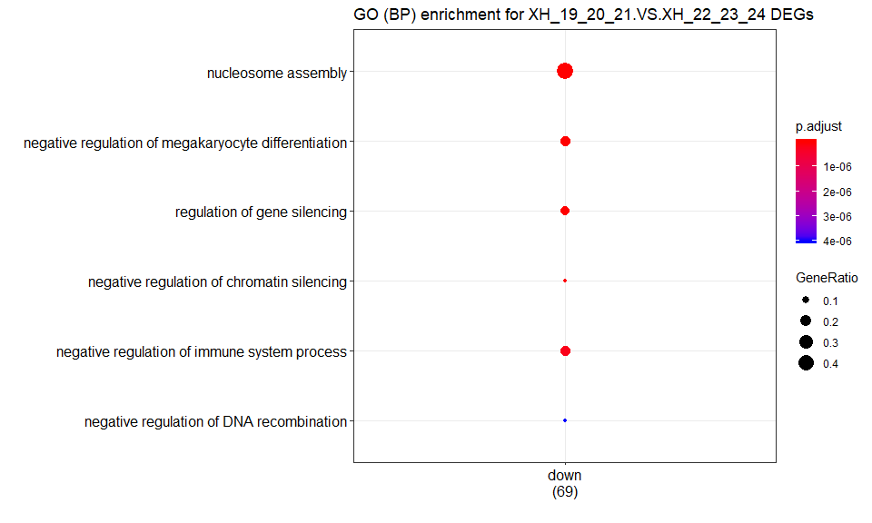

```r
# Plot both analysis results
dotplot(lineage1_ego, title="GO (BP) enrichment for XH_19_20_21.VS.XH_22_23_24 DEGs", showCategory=6)
```